# Práctica 7

Garcia Giron A

13/12/2020

Antes de nada.

la duda que se planteó en clase por el profesor sobre el pico en la cotización de volkswagen en 2008 se debe a que en esa fecha (octubre de 2008), la acción subió un 146%, se debió a que Porsche, primera accionista del grupo, anunció que aumentaba su participación en esta.

En este trabajo tenemos que entrar a valorar como afecto en las series temporales del valor de las acciones de las automovilísticas alemanas el boom del diesel de 2015 cuando volkswagen trucó los catalizadores que detectavan un volumen sustancialmente inferior de las emisiones de sus vehiculos para poder pasar las normativas de emisiones de Co2.

Vamos a ver el efecto de las consecuencias de esta maniobra de wv.

```r
#Carga de librerias
library(dplyr)
library(readr)
library(xts)
```

```r
library(ggplot2)
library(tidyr)
library(tseries)
library(CausalImpact)
inicio = "2014-01-01"  #iniciamos la serie
enclave = "2015-09-01"   #fecha de noticia
final = "2020-11-01"   #final del análisis
antes_de = as.Date(c(inicio, enclave))   # a priori
despues_de = as.Date(c(enclave, final))    # a posteriori
```

```r
#carga de datos de la compañias
Volkswagen = get.hist.quote(instrument = 'VOW.DE',
                            start = inicio,
                            end = final,
                            quote = 'Adj',
                            compression = 'w')
```

[output not shown]

```
## time series ends   2020-10-28
```

```r
BMW = get.hist.quote(instrument = 'BMW.DE',
                            start = inicio,
                            end = final,
                            quote = 'Adj',
                            compression = 'w')
```

```
## time series ends   2020-10-28
```

```r
BMW=na.omit(BMW) #eliminamos na
Volkswagen=na.omit(Volkswagen) #idem
```

```r
#juntamos los valores
stocks <- cbind(Volkswagen, BMW)
stocks_alreves <- cbind(BMW, Volkswagen)
```

```r
# ahora utilizamos #CausalImpact visualizemos: #como cambio estructural en econometria mira apuntes
impact <- CausalImpact(data = stocks,
                       pre.period = antes_de,
                       post.period = despues_de)
#cvamos laos rdos
summary(impact)
```

```
## Posterior inference {CausalImpact}
##
##                          Average        Cumulative
## Actual                   136            36748
## Prediction (s.d.)        158 (2.7)      42740 (719.0)
## 95% CI                   [153, 164]     [41303, 44146]
##
## Absolute effect (s.d.)   -22 (2.7)      -5991 (719.0)
## 95% CI                   [-27, -17]     [-7397, -4555]
##
## Relative effect (s.d.)   -14% (1.7%)    -14% (1.7%)
## 95% CI                   [-17%, -11%]   [-17%, -11%]
##
## Posterior tail-area probability p:   0.00112
## Posterior prob. of a causal effect:  99.88814%
##
## For more details, type: summary(impact, "report")
```

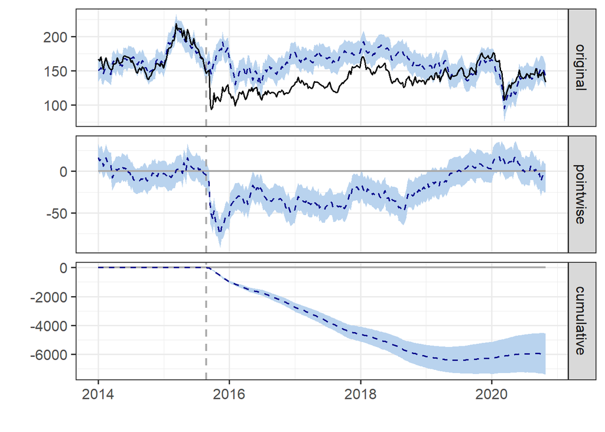

```r
plot(impact)
```

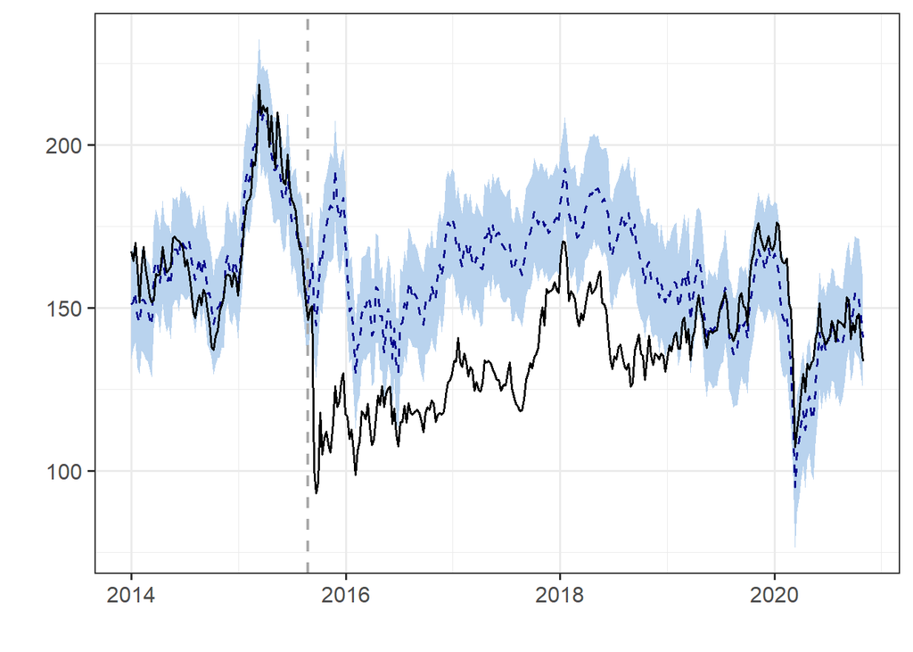

```r
plot(impact, "original")
```

Ahí se ve de manera claro como afectó la multa que le impusieron los órganos pertinentes de EEUU a la multinacional Alemana.

```r
summary(impact, "report")
```

[output not shown]

graficamente: Es eveidente numericamente: de acuerdo con el reort la acción de vag perdio un 14% a partir de ese septiembre de 2015

## C.I.BMW

```r
impact_BMW <- CausalImpact(data = stocks_alreves,
                       pre.period = antes_de, #EX ANTE
                       post.period = despues_de) #ex post
#comprobamos

summary(impact_BMW)
```

```
## Posterior inference {CausalImpact}
##
##                          Average       Cumulative
## Actual                   67            17978
## Prediction (s.d.)        60 (1.4)      16198 (367.0)
## 95% CI                   [58, 63]      [15528, 16905]
##
## Absolute effect (s.d.)   6.6 (1.4)     1780.4 (367.0)
## 95% CI                   [4, 9.1]      [1073, 2450.4]
##
## Relative effect (s.d.)   11% (2.3%)    11% (2.3%)
## 95% CI                   [6.6%, 15%]   [6.6%, 15%]
##
## Posterior tail-area probability p:   0.00275
## Posterior prob. of a causal effect:  99.72527%
##
## For more details, type: summary(impact, "report")
```

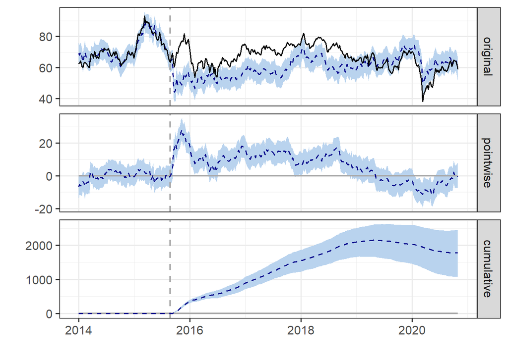

```r
plot(impact_BMW)
```

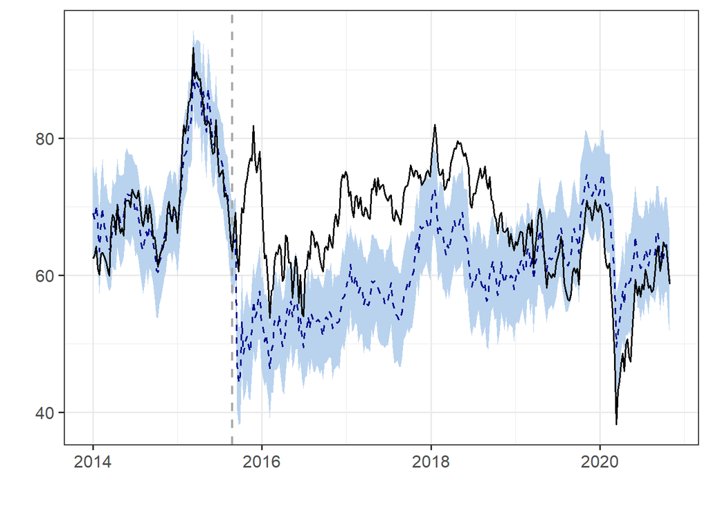

```r
plot(impact_BMW, "original")
```

graficamente: Es eveidente numericamente: de acuerdo con el report la acción de las fábricas Bábaras aumento un 11% a partir de ese septiembre de 2015

```r
summary(impact_BMW, "report")
```

[output not shown]

En conclusión es logico que la compañia bábara subiera un 11 desde el momento del cambio estructural. en algunos modelos pueden ser bienes sustitutivos por ende el consumidor y el inversor apoto por una compañía sólida del mismo sector donde, hasta el momento, la honestidad no había sido comprimetida.